# Marine Ecological Modelling Global Climate Change

Jorge Assis, PhD // Centre of Marine Sciences, University of Algarve

## Environmental data

## Environmental data

In ecological modelling we often aim to understand the relationship between the environment and the spatial patterns of biodiversity. Raster layers can be produced with temporal data (monthly) to generate biologically meaningful climatologies describing long-term environmental conditions.

### Terrestrial environmental layers : worldclim

WorldClim has climate data for minimum, mean, and maximum temperature and for precipitation, for the period 1970-2000. Downloads can be made at different spatial resolutions, from 30 seconds (~1 km2) to 10 minutes (~340 km2).

- Valid names in worldclim are ‘tmin’, ‘tmax’, ‘prec’ and ‘bio’;
- Valid resolutions are 0.5, 2.5, 5, and 10 (minutes of a degree);
- In the case of res=0.5, you must also provide a lon and lat argument for a tile;
- In all cases there are 12 (monthly) files for each variable except for ‘bio’ which contains 19 files.

Check ?getData or https://www.worldclim.org/bioclim for more information.

S5 // Environmental data in R

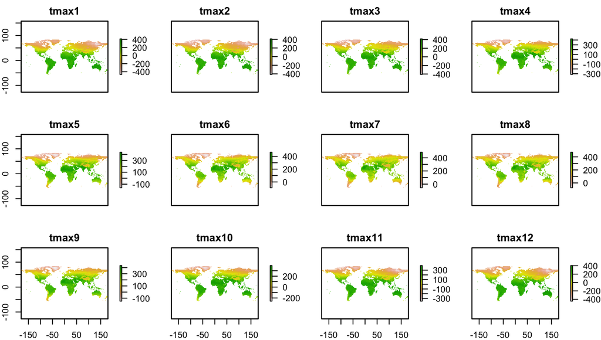

```r
# get terrestrial climate from worldclim as a stack of raster layers
airTempMaxMonths <- getData("worldclim", var = "tmax", res = 10, download = T)
plot(airTempMaxMonths)
```

S5 // Environmental data in R

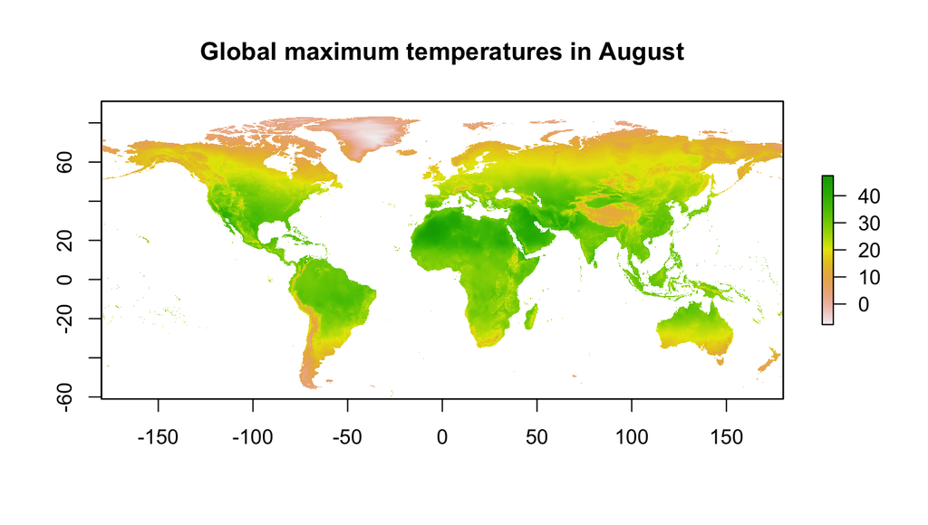

```r
# subset a raster layer from a stack of raster layers
airTempMaxAugust <- subset(airTempMaxMonths, 8)

# worldClim data has a scale factor of 10
airTempMaxAugust <- airTempMaxAugust/10

# plot raster layer
plot(airTempMaxAugust, main = "Global maximum temperatures in August")
```

S5 // Environmental data in R

### Marine environmental layers : Bio-ORACLE

Check ?sdmpredictors or https://bio-oracle.org for more information.

```r
# list all layers for the present
layerCodes <- list_layers(datasets = "Bio-ORACLE")
```

```r
# list all layers for the present; use View(layerCodes)
head(layerCodes)
```

|  | layer_code | name |
| --- | --- | --- |
| 69 | BO_calcite | Calcite (mean) |
| 70 | BO_chlomax | Chlorophyll A (maximum) |
| 71 | BO_chlomean | Chlorophyll A (mean) |
| 72 | BO_chlomin | Chlorophyll A (minimum) |
| 73 | BO_chlorange | Chlorophyll A (range) |
| 74 | BO_cloudmax | Cloud fraction (maximum) |

S5 // Environmental data in R

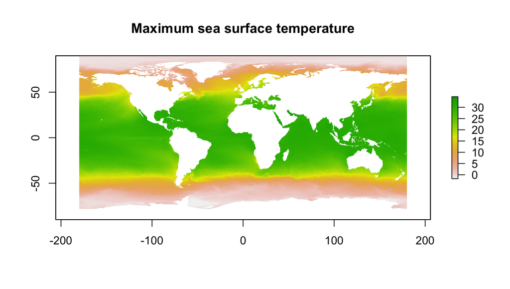

```r
# load layer of maximum sea surface temperature (ss)
maximumThermalConditions <- load_layers("BO2_tempmax_ss")
plot(maximumThermalConditions, main = "Maximum sea surface temperature")
```

S5 // Environmental data in R

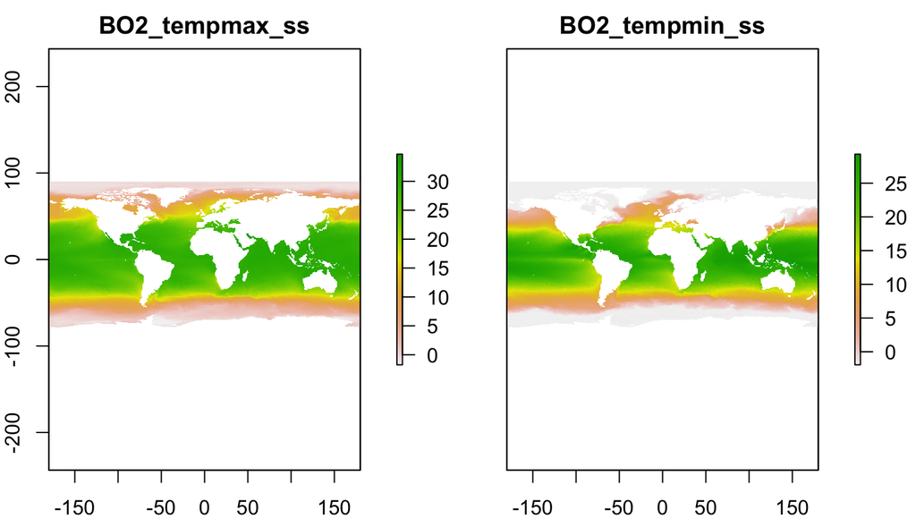

```r
# load layers of sea surface temperatures (max. and min.)
thermalConditions <- load_layers(c("BO2_tempmax_ss", "BO2_tempmin_ss"))
plot(thermalConditions)
```

S5 // Environmental data in R

```r
# list all layers for the future
layerCodesFuture <- list_layers_future(datasets = "Bio-ORACLE")
```

```r
head(layerCodesFuture)
```

| dataset_code | layer_code | current_layer_code | model | scenario | year | version |
| --- | --- | --- | --- | --- | --- | --- |
| Bio-ORACLE | BO_A1B_2100_salinity | BO_salinity | UKMO-HadCM3 | A1B | 2100 | 1 |
| Bio-ORACLE | BO_A1B_2100_sstmax | BO_sstmax | UKMO-HadCM3 | A1B | 2100 | 1 |
| Bio-ORACLE | BO_A1B_2100_sstmean | BO_sstmean | UKMO-HadCM3 | A1B | 2100 | 1 |
| Bio-ORACLE | BO_A1B_2100_sstmin | BO_sstmin | UKMO-HadCM3 | A1B | 2100 | 1 |
| Bio-ORACLE | BO_A1B_2100_sstrange | BO_sstrange | UKMO-HadCM3 | A1B | 2100 | 1 |
| Bio-ORACLE | BO_A1B_2200_salinity | BO_salinity | UKMO-HadCM3 | A1B | 2200 | 1 |

S5 // Environmental data in R

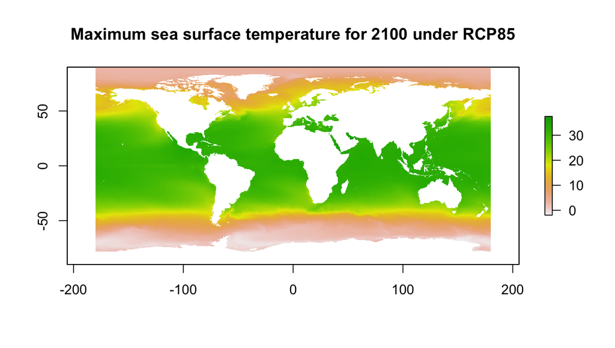

```r
# load layer of maximum sea surface temperature projected for 2100 under RCP85
maximumThermalConditions <- load_layers("BO2_RCP85_2100_templtmax_ss")
plot(maximumThermalConditions, main = "Maximum sea surface temperature for 2100 under RCP85")
```

S5 // Environmental data in R

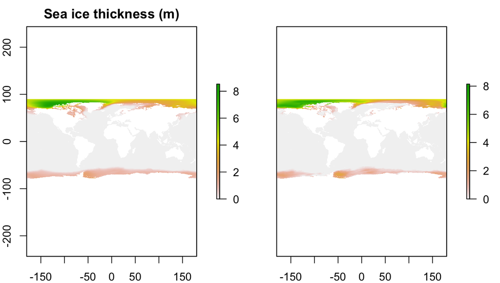

```r
# plot ice for the present
iceThickMinPresent <- load_layers("BO2_icethickltmax_ss")
iceThickMaxRCP85 <- load_layers("BO2_RCP85_2100_icethickmax_ss")
iceConditions <- stack(iceThickMinPresent, iceThickMaxRCP85)
plot(iceConditions, axes = TRUE, main = "Sea ice thickness (m)", ylab = "Lat", xlab = "Lon")
```

S5 // Environmental data in R

### Challenge 5.1

The main objetive of this challenge is to **plot** the maximum sea surface temperature in Europe for the year 2100 under two contrasting scenarios of climate change (RCP26 and RCP85)

**Packages, data and functions to accomplish the challenge:**

European coastline extent: xmin = -15; xmax = 40; ymin = 25; ymax = 70.5  
Bio-ORACLE layer: Sea water temperature (maximum)  
source(“sourceFunctions.R”)  
list_layers(datasets = “Bio-ORACLE”)  
list_layers_future(datasets = “Bio-ORACLE”)  
View()  
load_layers()  
extent(object)  
crop(object)  
plot(object)

S5 // Environmental data in R

### Challenge 5.2

The main objetive of this challenge is to **plot** the difference in global maximum sea surface temperature between the present and the year 2100 under two contrasting scenarios of climate change (RCP26 and RCP85)

**Packages, data and functions to accomplish the challenge:**

Bio-ORACLE layer: Sea water temperature (maximum)  
source(“sourceFunctions.R”)  
list_layers(datasets = “Bio-ORACLE”)  
list_layers_future(datasets = “Bio-ORACLE”)  
View()  
load_layers()  
plot(object)

S5 // Environmental data in R

### Challenge 5.3

The main objetive of this challenge is to **plot** the difference in sea ice thickness between the present and the year 2100 under two contrasting scenarios of climate change (RCP26 and RCP85).

**Packages, data and functions to accomplish the challenge:**

Bio-ORACLE layer: Sea ice thickness (maximum)  
source(“sourceFunctions.R”)  
list_layers(datasets = “Bio-ORACLE”)  
list_layers_future(datasets = “Bio-ORACLE”)  
View()  
load_layers()  
plot(object)

S5 // Environmental data in R

### Challenge 5.4

The main objetive of this challenge is to **plot** the difference in sea temperature between the surface and bottom layers of the ocean.

**Packages, data and functions to accomplish the challenge:**

Bio-ORACLE layers: Sea water temperature (maximum); Sea water temperature (maximum at mean depth)  
source(“sourceFunctions.R”)  
list_layers(datasets = “Bio-ORACLE”)  
View()  
load_layers()  
plot(object)

S5 // Environmental data in R

### Challenge 5.5

The main objetive of this assignment is to **extract** the thermal conditions use (values) of the mediterranean coral Paramuricea clavata for the present. Use GBIF data for this assignment.

**Packages, data and functions to accomplish the challenge:**

Bio-ORACLE layers: Sea water temperature (maximum at mean depth)  
source(“sourceFunctions.R”)  
“Data/dataBases/Paramuricea_clavata.csv”  
read.csv(path,sep=“;”)  
list_layers(datasets = “Bio-ORACLE”)  
View()  
load_layers()  
colnames(object)  
extract(object)  
summary(object)  
hist(object)

S5 // Environmental data in R

### Challenge 5.6 [see solution of challenge 2.9]

The main objetive of this challenge is to **reclassify** a set of environmental **rasters** and plot the potential habitat of a marine forest species (Saccorhiza polyschides) in European coastlines for the present and the future (year 2100 RCP 85) using a mechanistic approach (i.e., process based model). Compare ranges between time periods. Suitable conditions set by:

Light > 5; Salinity > 10; Max Temp < 20.5; Min Temp > 5 (Lobban & Wynne, 1981; Assis et al., 2017)

**Packages, data and functions to accomplish the challenge:**

Bio-ORACLE layers: Sea water temperature (maximum at mean depth); Sea water temperature (minimum at mean depth); Salinity (minimum at mean depth); Light (mean at mean depth)  
source(“sourceFunctions.R”)  
list_layers(datasets = “Bio-ORACLE”)  
list_layers_future(datasets = “Bio-ORACLE”)  
load_layers()  
View()  
data.frame()  
reclassify()  
crop(object,extent(xmin,xmax,ymin,ymax))  
plot(object)

S5 // Environmental data in R

### Challenge 5.7

The main objetive of this challenge is to assess **collinearity** (high correlation) between a set of variables and region of your interest.

**Packages, data and functions to accomplish the challenge:**

Bio-ORACLE layers: …  
source(“sourceFunctions.R”)  
list_layers(datasets = “Bio-ORACLE”)  
load_layers()  
View()  
crop(object,extent(xmin,xmax,ymin,ymax))  
plot(object)  
pairs(object)

S5 // Environmental data in R

## References

Global change impacts on biodiversity. Available at: https://damariszurell.github.io/HU-GCIB

Copyright (c) Earth Lab. Available at: https://www.earthdatascience.org.

Open Science for Synthesis: Gulf Research Program Workshop. Available at: https://github.com/NCEAS/oss-lessons

Gimond, M. (2019) Intro to GIS and Spatial Analysis. Available at: https://mgimond.github.io/Spatial/